# Master_Юлия Шаталина_review (1)

### 2.2 Формирование новых признаков, шкалирование, кодирование

```python
df_features = df_history.groupby('client_id').agg(
    {'quantity':['sum'],
      'price': ['sum', 'median'],
      'date': ['min', 'max']}
)
```

```python
df_features
```

| client_id | quantity sum | price sum | price median | date min | date max |
| --- | --- | --- | --- | --- | --- |
| 1515915625440099873 | 2 | 33216.0 | 16608.0 | 2023-07-16 08:25:31 | 2023-08-09 08:59:08 |
| 1515915625440939402 | 1 | 75998.0 | 75998.0 | 2023-01-30 13:13:37 | 2023-01-30 13:13:37 |
| 1515915625440944408 | 3 | 81178.0 | 6298.0 | 2023-03-01 10:21:12 | 2023-06-21 12:20:06 |
| 1515915625440947454 | 4 | 4486.0 | 243.0 | 2022-11-06 17:14:50 | 2022-12-24 16:35:42 |
| 1515915625440952940 | 1 | 479.0 | 479.0 | 2022-11-11 05:17:51 | 2022-11-11 05:17:51 |
| ... | ... | ... | ... | ... | ... |
| 1515915625996380624 | 6 | 70251.0 | 6652.0 | 2023-08-30 00:00:00 | 2023-08-30 00:00:00 |
| 1515915625997511191 | 1 | 15043.0 | 15043.0 | 2023-08-18 00:00:00 | 2023-08-18 00:00:00 |
| 1515915625997770678 | 5 | 104177.0 | 6501.0 | 2023-08-18 00:00:00 | 2023-08-18 00:00:00 |
| 1515915626005014483 | 1 | 7534.0 | 7534.0 | 2023-09-13 00:00:00 | 2023-09-13 00:00:00 |
| 1515915626012131867 | 1 | 25834.0 | 25834.0 | 2023-09-12 00:00:00 | 2023-09-12 00:00:00 |

44678 rows × 5 columns

Переименуем столбцы и сбросим индексацию датасета после группировки

```python
df_features.columns= ['_'.join(col) for col in df_features]
```

```python
df_features= df_features.reset_index()
```

Введем новые фичи - в течении какого срока пользователь активно покупает (разница между первым и последним днем покупки), и как давно была совершена покупка с последнего дня датасета.

```python
df_features['period_total'] = (df_features['date_max'] - df_features['date_min']).dt.days
```

```python
df_features['last_date'] = (df_apparel['date'].max() - df_features['date_max']).dt.days
```

Удалим ненужные столбцы с датами. Сформируем таргет.

```python
df_features= df_features.drop(['date_min','date_max'], axis=1)
```

```python
df_features['target'] = 0
```

```python
df_features
```

|  | client_id | quantity_sum | price_sum | price_median | period_total | last_date | target |
| --- | --- | --- | --- | --- | --- | --- | --- |
| 0 | 1515915625440099873 | 2 | 33216.0 | 16608.0 | 24 | 77 | 0 |
| 1 | 1515915625440939402 | 1 | 75998.0 | 75998.0 | 0 | 268 | 0 |
| 2 | 1515915625440944408 | 3 | 81178.0 | 6298.0 | 112 | 126 | 0 |
| 3 | 1515915625440947454 | 4 | 4486.0 | 243.0 | 47 | 305 | 0 |
| 4 | 1515915625440952940 | 1 | 479.0 | 479.0 | 0 | 348 | 0 |
| ... | ... | ... | ... | ... | ... | ... | ... |
| 44673 | 1515915625996380624 | 6 | 70251.0 | 6652.0 | 0 | 57 | 0 |
| 44674 | 1515915625997511191 | 1 | 15043.0 | 15043.0 | 0 | 69 | 0 |
| 44675 | 1515915625997770678 | 5 | 104177.0 | 6501.0 | 0 | 69 | 0 |
| 44676 | 1515915626005014483 | 1 | 7534.0 | 7534.0 | 0 | 43 | 0 |
| 44677 | 1515915626012131867 | 1 | 25834.0 | 25834.0 | 0 | 44 | 0 |

44678 rows × 7 columns

Заполним значениями 1 строки 'target' по 'client_id', которые купили что-то в последнем месяце наблюдений.

```python
df_features.loc[df_features['client_id'].isin(positive_target), 'target'] = 1
```

Вернем разметку по магазинам.

```python
df_merged= df_features.merge(df[['client_id','market']])
```

```python
df_merged = df_merged.drop_duplicates()
```

```python
df_merged.reset_index()
```

|  | index | client_id | quantity_sum | price_sum | price_median | period_total | last_date | target | market |
| --- | --- | --- | --- | --- | --- | --- | --- | --- | --- |
| 0 | 0 | 1515915625440099873 | 2 | 33216.0 | 16608.0 | 24 | 77 | 0 | 2 |
| 1 | 2 | 1515915625440939402 | 1 | 75998.0 | 75998.0 | 0 | 268 | 0 | 2 |
| 2 | 3 | 1515915625440944408 | 3 | 81178.0 | 6298.0 | 112 | 126 | 0 | 2 |
| 3 | 6 | 1515915625440947454 | 4 | 4486.0 | 243.0 | 47 | 305 | 0 | 2 |
| 4 | 10 | 1515915625440952940 | 1 | 479.0 | 479.0 | 0 | 348 | 0 | 2 |
| ... | ... | ... | ... | ... | ... | ... | ... | ... | ... |
| 44673 | 176008 | 1515915625996380624 | 6 | 70251.0 | 6652.0 | 0 | 57 | 0 | 1 |
| 44674 | 176014 | 1515915625997511191 | 1 | 15043.0 | 15043.0 | 0 | 69 | 0 | 1 |
| 44675 | 176015 | 1515915625997770678 | 5 | 104177.0 | 6501.0 | 0 | 69 | 0 | 1 |
| 44676 | 176020 | 1515915626005014483 | 1 | 7534.0 | 7534.0 | 0 | 43 | 0 | 1 |
| 44677 | 176021 | 1515915626012131867 | 1 | 25834.0 | 25834.0 | 0 | 44 | 0 | 1 |

44678 rows × 9 columns

```python
df_merged.info()
```

```
<class 'pandas.core.frame.DataFrame'>
Index: 44678 entries, 0 to 176021
Data columns (total 8 columns):
 #   Column        Non-Null Count  Dtype
---  ------        --------------  -----
 0   client_id     44678 non-null  int64
 1   quantity_sum  44678 non-null  int64
 2   price_sum     44678 non-null  float64
 3   price_median  44678 non-null  float64
 4   period_total  44678 non-null  int64
 5   last_date     44678 non-null  int64
 6   target        44678 non-null  int64
 7   market        44678 non-null  int64
dtypes: float64(2), int64(6)
memory usage: 3.1 MB
```

Получаем итоговый датасет с фичами обучения и таргет. Проверим дисбаланс классов

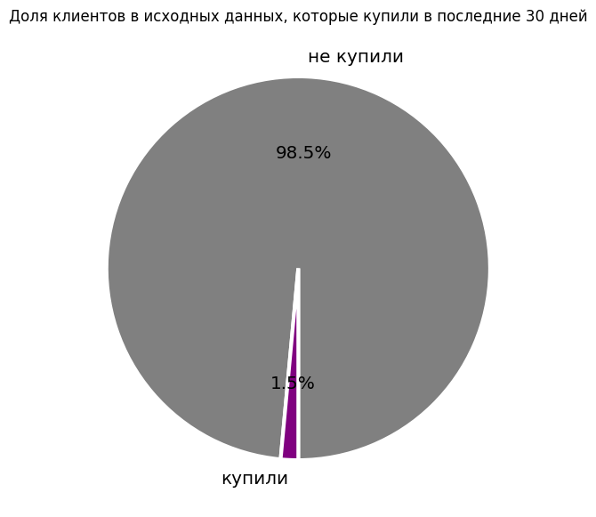

```python
sizes = df_merged['target'].value_counts(sort = True)
colors = ["grey","purple"]
fig, axes = plt.subplots(1, figsize = (7,7))
labels= ['не купили', 'купили']

plt.pie(sizes,
        colors=colors,
        autopct='%1.1f%%',
        startangle=270,
        wedgeprops={'linewidth': 3.0, 'edgecolor': 'white'},
        textprops={'size': 'x-large'},
        labels = labels,
        )

plt.title('Доля клиентов в исходных данных, которые купили в последние 30 дней')
plt.show()
```

```python
df_merged['target'].value_counts()
```

```
target
0    44023
1      655
Name: count, dtype: int64
```

Дисбаланс классов большой, всего 1,5 % клиентов от общего числа купили товары в последние 30 дней